# Microsoft Malware detection

### 4.2.2 Univariate analysis on asm file features

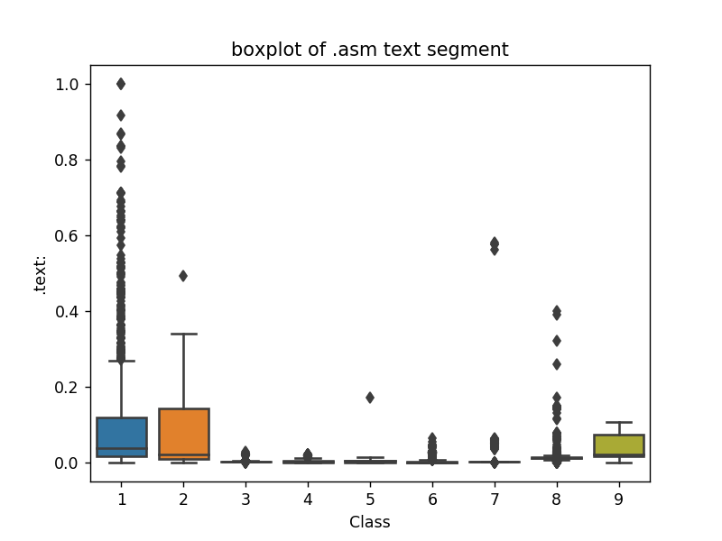

```python
ax = sns.boxplot(x="Class", y=".text:", data=result_asm)
plt.title("boxplot of .asm text segment")
plt.show()
```

```
The plot is between Text and class
Class 1,2 and 9 can be easly separated
```

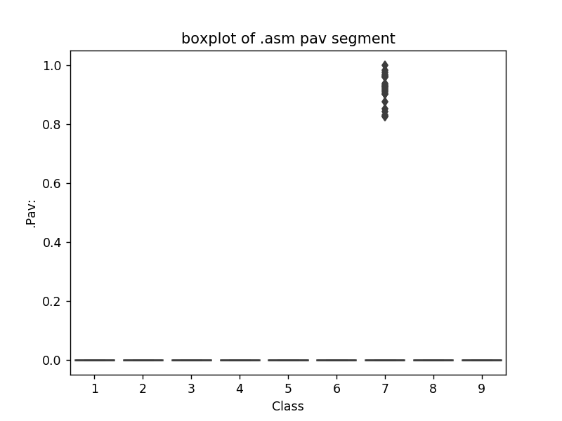

```python
ax = sns.boxplot(x="Class", y=".Pav:", data=result_asm)
plt.title("boxplot of .asm pav segment")
plt.show()
```

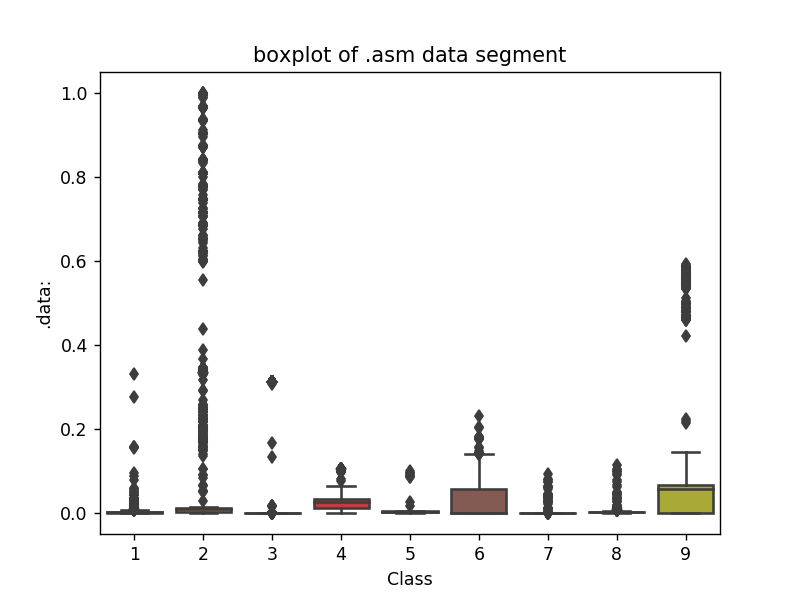

```python
ax = sns.boxplot(x="Class", y=".data:", data=result_asm)
plt.title("boxplot of .asm data segment")
plt.show()
```

```
The plot is between data segment and class label
class 6 and class 9 can be easily separated from given points
```

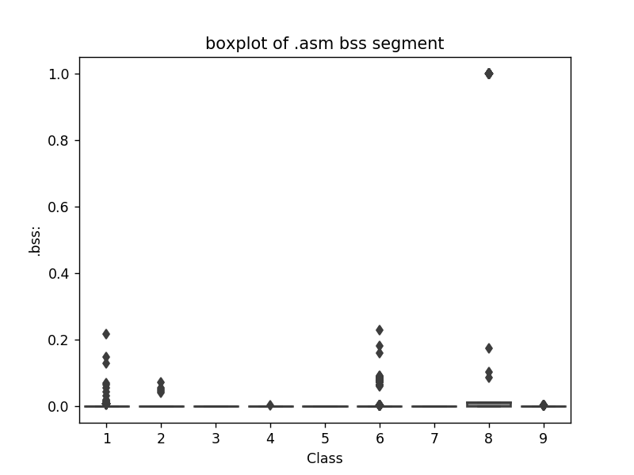

```python
ax = sns.boxplot(x="Class", y=".bss:", data=result_asm)
plt.title("boxplot of .asm bss segment")
plt.show()
```

```
plot between bss segment and class label
very less number of files are having bss segment
```

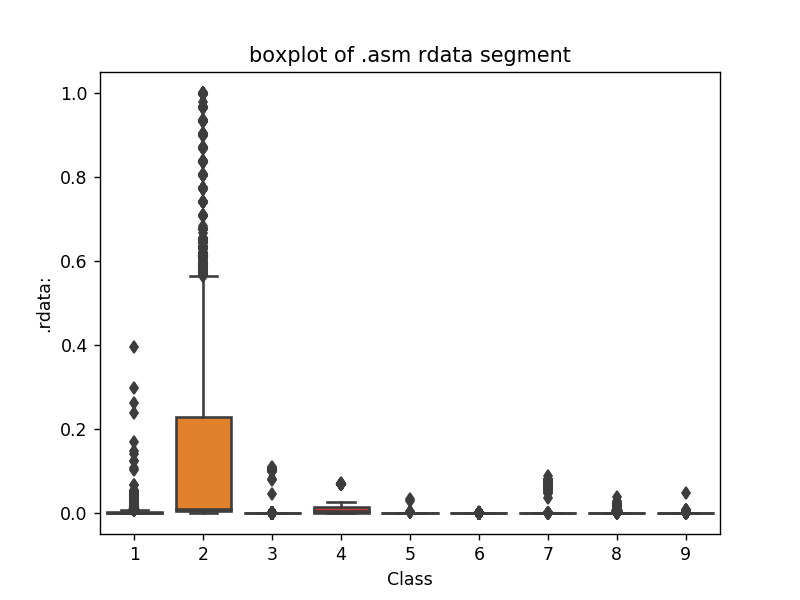

```python
ax = sns.boxplot(x="Class", y=".rdata:", data=result_asm)
plt.title("boxplot of .asm rdata segment")
plt.show()
```

```
Plot between rdata segment and Class segment
Class 2 can be easily separated 75 pecentile files are having 1M rdata lines
```

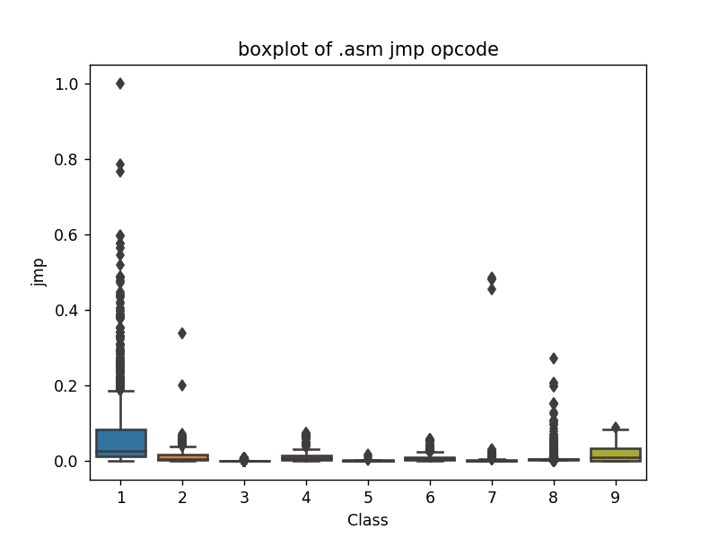

```python
ax = sns.boxplot(x="Class", y="jmp", data=result_asm)
plt.title("boxplot of .asm jmp opcode")
plt.show()
```

```
plot between jmp and Class label
Class 1 is having frequency of 2000 approx in 75 perentile of files
```

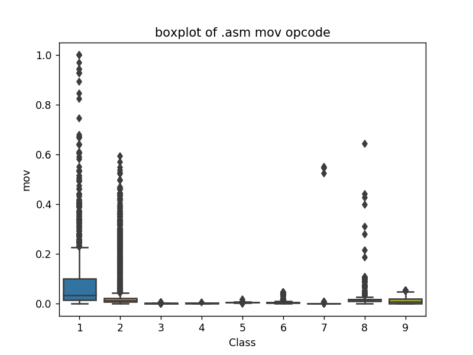

```python
ax = sns.boxplot(x="Class", y="mov", data=result_asm)
plt.title("boxplot of .asm mov opcode")
plt.show()
```

```
plot between Class label and mov opcode
Class 1 is having frequency of 2000 approx in 75 perentile of files
```

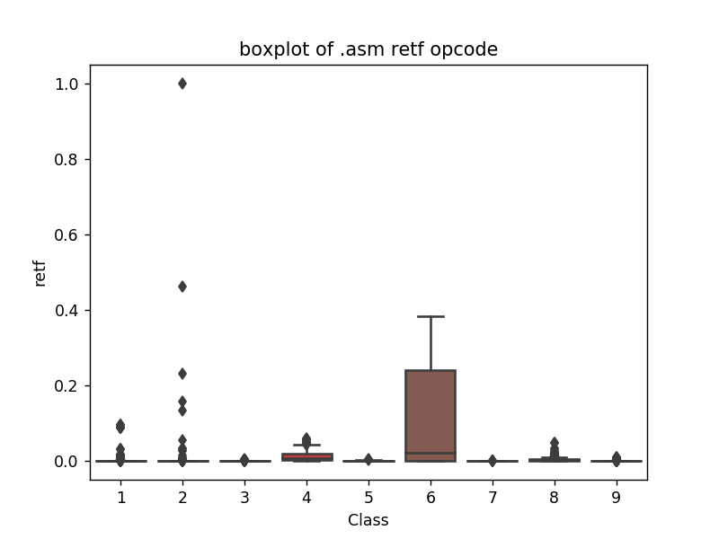

```python
ax = sns.boxplot(x="Class", y="retf", data=result_asm)
plt.title("boxplot of .asm retf opcode")
plt.show()
```

```
plot between Class label and retf
Class 6 can be easily separated with opcode retf
The frequency of retf is approx of 250.
```

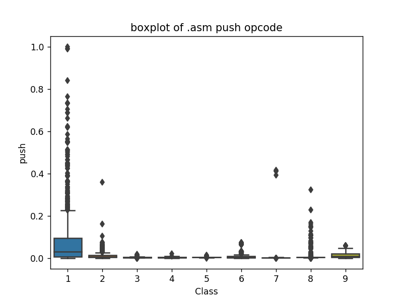

```python
ax = sns.boxplot(x="Class", y="push", data=result_asm)
plt.title("boxplot of .asm push opcode")
plt.show()
```

```
plot between push opcode and Class label
Class 1 is having 75 precentile files with push opcodes of frequency 1000
```

```python
from PIL import Image
from pathlib import Path
asm_file_name = []
asm_arrays = []
if os.path.isdir('asm_image'):
    data_files = os.listdir('asm_image')
    for file in data_files:
        name=file.split('.')[0]
        asm_file_name.append(name)

        im = Image.open('asm_image/'+file,'r')
        pix_val = list(im.getdata())
        asm_arrays.append(pix_val)

asm_arrays = np.array(asm_arrays)
column_name = ['pixel : ' + str(i) for i in range(len(asm_arrays[0]))]

dic = {column_name[i]:asm_arrays[:,i] for i in range(len(asm_arrays[0]))}
dic.update({'ID':asm_file_name})

asm_file = pd.DataFrame(dic)
asm_file.to_csv('asm_file.csv')
```

```python
dfasm=pd.read_csv("asm_file.csv")
dfasm.shape
```

```
(10861, 5002)
```

```python
dfasm.head(2)
```

|  | Unnamed: 0 | pixel : 0 | pixel : 1 | pixel : 2 | pixel : 3 | pixel : 4 | pixel : 5 | pixel : 6 | pixel : 7 | pixel : 8 | pixel : 9 | pixel : 10 | pixel : 11 | pixel : 12 | pixel : 13 | pixel : 14 | pixel : 15 | pixel : 16 | pixel : 17 | pixel : 18 | pixel : 19 | pixel : 20 | pixel : 21 | pixel : 22 | pixel : 23 | pixel : 24 | pixel : 25 | pixel : 26 | pixel : 27 | … |
| --- | --- | --- | --- | --- | --- | --- | --- | --- | --- | --- | --- | --- | --- | --- | --- | --- | --- | --- | --- | --- | --- | --- | --- | --- | --- | --- | --- | --- | --- | --- |
| 0 | 0 | 68 | 71 | 69 | 66 | 65 | 88 | 60 | 39 | 51 | 54 | 41 | 48 | 43 | 49 | 45 | 16 | 13 | 5 | 10 | 15 | 0 | 25 | 58 | 13 | 3 | 77 | 72 | 70 | … |
| 1 | 1 | 68 | 71 | 69 | 66 | 65 | 88 | 60 | 39 | 51 | 54 | 41 | 48 | 43 | 49 | 45 | 16 | 13 | 5 | 10 | 15 | 0 | 25 | 58 | 13 | 3 | 77 | 72 | 70 | … |

2 rows × 5002 columns

```python
dfasm = dfasm.drop(columns=['ID','Unnamed: 0'])
```

```python
dfasm.shape
```

```
(10861, 5000)
```

```python
from sklearn.decomposition import TruncatedSVD
#Desired dimensionality of output data. Must be strictly less than the number of features
max_features = 5000 - 1
svd = TruncatedSVD(n_components=max_features)
svd_data = svd.fit_transform(dfasm)
percentage_var_explained = svd.explained_variance_ / np.sum(svd.explained_variance_)
cum_var_explained = np.cumsum(percentage_var_explained)
```

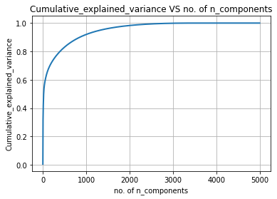

```python
%matplotlib inline
# Plot the TrunvatedSVD spectrum
plt.figure(1, figsize=(6, 4))
plt.clf()
plt.plot(cum_var_explained, linewidth=2)
plt.grid()
plt.xlabel('no. of n_components')
plt.ylabel('Cumulative_explained_variance')
plt.title("Cumulative_explained_variance VS no. of n_components")
plt.show()
```

```python
Optimal_components=3000

svd_trunc = TruncatedSVD(n_components=Optimal_components)
svd_transform = svd_trunc.fit_transform(dfasm)

print("Shape of data : ",svd_transform.shape)
```

```
Shape of data :  (10861, 3000)
```

```python
from PIL import Image
from pathlib import Path
asm_file_name = []
asm_arrays = []
if os.path.isdir('asm_image'):
    data_files = os.listdir('asm_image')
    for file in data_files:
        name=file.split('.')[0]
        asm_file_name.append(name)
```

```python
column_name = ['pixel : ' + str(i) for i in range(5000)]
best_fearures = [column_name[i] for i in svd_trunc.components_[0].argsort()[::-1][0:3000]]

dic = {best_fearures[i]:svd_transform[:,i] for i in range(3000)}
dic.update({'ID':asm_file_name})

asm_data = pd.DataFrame(dic)
```

```python
asm_data.head(5)
```

|  | pixel : 280 | pixel : 192 | pixel : 213 | pixel : 284 | pixel : 184 | pixel : 308 | pixel : 410 | pixel : 170 | pixel : 194 | pixel : 171 | pixel : 303 | pixel : 210 | pixel : 224 | pixel : 299 | pixel : 295 | pixel : 207 | pixel : 179 | pixel : 285 | pixel : 206 | pixel : 177 | pixel : 199 | pixel : 315 | pixel : 301 | pixel : 198 | pixel : 304 | pixel : 279 | pixel : 183 | pixel : 383 | pixel : 176 | … |
| --- | --- | --- | --- | --- | --- | --- | --- | --- | --- | --- | --- | --- | --- | --- | --- | --- | --- | --- | --- | --- | --- | --- | --- | --- | --- | --- | --- | --- | --- | --- |
| 0 | 4028.073683 | -621.378059 | -825.289935 | 44.564605 | 36.028959 | 5.400591 | 16.103856 | -195.450080 | -54.094948 | -94.628160 | -55.304150 | 34.171393 | -50.241496 | 1.319289 | 19.759012 | -15.987964 | 19.827760 | 26.014244 | -9.549313 | -40.276612 | -71.801977 | -90.672152 | 59.059060 | 16.976157 | -109.833036 | -136.241724 | -85.122260 | 34.058002 | 2.601309 | … |
| 1 | 4043.842574 | -596.088299 | -819.683412 | 53.186070 | 12.052960 | -40.500301 | -40.560276 | -185.352045 | -39.563901 | -98.096166 | -32.447496 | 34.683291 | -61.711333 | 18.592599 | 28.989351 | -38.804119 | 0.522969 | 48.274450 | -26.393670 | 97.152770 | -77.206624 | -71.232177 | 63.807769 | -35.546775 | 29.836266 | -146.343337 | -235.951385 | -6.211015 | -29.542509 | … |
| 2 | 3978.625730 | -197.593367 | 620.467642 | 823.947573 | -1038.939364 | -868.822069 | -356.841591 | -173.415540 | -45.200470 | 10.421191 | -23.285332 | -88.797480 | -160.750775 | 74.518173 | 37.811626 | -85.328196 | -33.214896 | 80.795361 | -307.489072 | -42.543422 | -10.489377 | 20.695517 | 9.785396 | 3.328923 | 42.011356 | -6.148446 | -30.980243 | 4.772223 | -20.833192 | … |
| 3 | 4076.798737 | 1803.476298 | -488.815765 | -375.889754 | -470.498151 | 316.888703 | -505.371024 | -18.417842 | 35.587903 | -6.421402 | 101.559309 | 59.293713 | -79.603621 | 104.798883 | -46.716055 | 29.152540 | 97.689195 | -32.117715 | 7.822545 | 43.351667 | 43.769264 | -22.914873 | 389.703470 | 601.033085 | 121.434869 | 25.024424 | 88.678284 | -30.314901 | 4.451451 | … |
| 4 | 3926.348769 | -213.216141 | 328.024635 | -57.563091 | -13.597400 | -67.282867 | 9.561821 | 311.221334 | -144.700815 | -194.759059 | 5.391663 | -77.451735 | -8.328226 | -63.776340 | -40.150013 | -60.832455 | 124.443010 | 57.470037 | 67.578833 | 45.998802 | 21.028199 | -37.355239 | 125.825062 | 7.060339 | -96.321938 | 88.511067 | -62.144304 | 62.110214 | 93.345145 | … |

5 rows × 3001 columns

```python
asm_size_data = pd.read_csv('asm_with_size.csv')
asm_size_data = asm_size_data.drop(columns=['Unnamed: 0'])
asm_size_data.head(5)
```

|  | ID | size_asm | Class |
| --- | --- | --- | --- |
| 0 | 01azqd4InC7m9JpocGv5 | 56.229886 | 9 |
| 1 | 01IsoiSMh5gxyDYTl4CB | 13.999378 | 2 |
| 2 | 01jsnpXSAlgw6aPeDxrU | 8.507785 | 9 |
| 3 | 01kcPWA9K2BOxQeS5Rju | 0.078190 | 1 |
| 4 | 01SuzwMJEIXsK7A8dQbl | 0.996723 | 8 |

```python
byte_features_with_size_asm = asm_data.merge(asm_size_data, on='ID')
byte_features_with_size_asm.to_csv("result_with_size_asm.csv")
byte_features_with_size_asm.head(2)
```

|  | pixel : 280 | pixel : 192 | pixel : 213 | pixel : 284 | pixel : 184 | pixel : 308 | pixel : 410 | pixel : 170 | pixel : 194 | pixel : 171 | pixel : 303 | pixel : 210 | pixel : 224 | pixel : 299 | pixel : 295 | pixel : 207 | pixel : 179 | pixel : 285 | pixel : 206 | pixel : 177 | pixel : 199 | pixel : 315 | pixel : 301 | pixel : 198 | pixel : 304 | pixel : 279 | pixel : 183 | pixel : 383 | pixel : 176 | … |
| --- | --- | --- | --- | --- | --- | --- | --- | --- | --- | --- | --- | --- | --- | --- | --- | --- | --- | --- | --- | --- | --- | --- | --- | --- | --- | --- | --- | --- | --- | --- |
| 0 | 4028.073683 | -621.378059 | -825.289935 | 44.564605 | 36.028959 | 5.400591 | 16.103856 | -195.450080 | -54.094948 | -94.628160 | -55.304150 | 34.171393 | -50.241496 | 1.319289 | 19.759012 | -15.987964 | 19.827760 | 26.014244 | -9.549313 | -40.276612 | -71.801977 | -90.672152 | 59.059060 | 16.976157 | -109.833036 | -136.241724 | -85.122260 | 34.058002 | 2.601309 | … |
| 1 | 4043.842574 | -596.088299 | -819.683412 | 53.186070 | 12.052960 | -40.500301 | -40.560276 | -185.352045 | -39.563901 | -98.096166 | -32.447496 | 34.683291 | -61.711333 | 18.592599 | 28.989351 | -38.804119 | 0.522969 | 48.274450 | -26.393670 | 97.152770 | -77.206624 | -71.232177 | 63.807769 | -35.546775 | 29.836266 | -146.343337 | -235.951385 | -6.211015 | -29.542509 | … |

2 rows × 3003 columns

```python
dfasm=pd.read_csv("asmoutputfile.csv")
dfasm.shape
```

```
(10868, 52)
```

```python
dfasm = dfasm.drop(columns=['ID'])
```

```python
from sklearn.decomposition import TruncatedSVD
#Desired dimensionality of output data. Must be strictly less than the number of features
max_features = 51-1
svd = TruncatedSVD(n_components=max_features)
svd_data = svd.fit_transform(dfasm)
percentage_var_explained = svd.explained_variance_ / np.sum(svd.explained_variance_)
cum_var_explained = np.cumsum(percentage_var_explained)
```

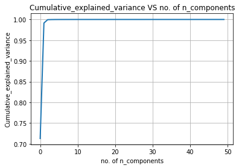

```python
%matplotlib inline
# Plot the TrunvatedSVD spectrum
plt.figure(1, figsize=(6, 4))
plt.clf()
plt.plot(cum_var_explained, linewidth=2)
plt.grid()
plt.xlabel('no. of n_components')
plt.ylabel('Cumulative_explained_variance')
plt.title("Cumulative_explained_variance VS no. of n_components")
plt.show()
```

```python
Optimal_components=20

svd_trunc = TruncatedSVD(n_components=Optimal_components)
svd_transform = svd_trunc.fit_transform(dfasm)

print("Shape of data : ",svd_transform.shape)
```

```
Shape of data :  (10868, 20)
```

```python
file_names = []
for i , row in dfasm['ID'].iteritems():
  file_names.append(row)
```

```python
column_name = [col for col in dfasm.columns]
```

```python
dic = {column_name[i]:svd_transform[:,i] for i in range(20)}
dic.update({'ID':file_names})

asm_data = pd.DataFrame(dic)
asm_data.head(2)
```

|  | ID | HEADER: | .text: | .Pav: | .idata: | .data: | .bss: | .rdata: | .edata: | .rsrc: | .tls: | .reloc: | .BSS: | .CODE | jmp | mov | retf | push | pop | xor |
| --- | --- | --- | --- | --- | --- | --- | --- | --- | --- | --- | --- | --- | --- | --- | --- | --- | --- | --- | --- | --- |
| 0 | 01kcPWA9K2BOxQeS5Rju | 60.084337 | 770.513000 | -48.622595 | 55.684512 | 30.350897 | 50.106603 | 4.286030 | 1.818266 | 123.882334 | 3.243021 | 9.756179 | -15.483190 | -7.638344 | 18.810672 | 29.615698 | 6.526542 | 4.198155 | 2.862721 | 47.405953 |
| 1 | 1E93CpP60RHFNiT5Qfvn | 59.386191 | 859.761233 | -78.242932 | 31.445927 | 38.780822 | -33.725334 | -12.136069 | 1.790523 | 97.816607 | 16.830043 | -9.452131 | 4.753698 | -10.902294 | 8.411942 | -17.381639 | 8.493083 | 0.400437 | 3.471027 | 3.028546 |

```python
byte_features_with_size_asm_pixel = asm_data.merge(byte_features_with_size_asm, on='ID')
byte_features_with_size_asm_pixel.to_csv("result_with_size_asm_pixel.csv")
byte_features_with_size_asm_pixel.head(2)
```

|  | ID | HEADER: | .text: | .Pav: | .idata: | .data: | .bss: | .rdata: | .edata: | .rsrc: | .tls: | .reloc: | .BSS: | .CODE | jmp | mov | retf | push | pop | xor | pixel : 280 | pixel : 192 | pixel : 213 | pixel : 284 | pixel : 184 | pixel : 308 | pixel : 410 | pixel : 170 | pixel : 194 | … |
| --- | --- | --- | --- | --- | --- | --- | --- | --- | --- | --- | --- | --- | --- | --- | --- | --- | --- | --- | --- | --- | --- | --- | --- | --- | --- | --- | --- | --- | --- | --- |
| 0 | 01kcPWA9K2BOxQeS5Rju | 60.084337 | 770.513000 | -48.622595 | 55.684512 | 30.350897 | 50.106603 | 4.286030 | 1.818266 | 123.882334 | 3.243021 | 9.756179 | -15.483190 | -7.638344 | 18.810672 | 29.615698 | 6.526542 | 4.198155 | 2.862721 | 47.405953 | 4488.172927 | -347.325395 | 809.381616 | -687.236845 | 201.409856 | -8.619725 | 22.720835 | -68.031808 | 519.592407 | … |
| 1 | 1E93CpP60RHFNiT5Qfvn | 59.386191 | 859.761233 | -78.242932 | 31.445927 | 38.780822 | -33.725334 | -12.136069 | 1.790523 | 97.816607 | 16.830043 | -9.452131 | 4.753698 | -10.902294 | 8.411942 | -17.381639 | 8.493083 | 0.400437 | 3.471027 | 3.028546 | 4669.755008 | -144.487275 | 87.008990 | -57.495807 | 93.117459 | -53.160254 | -3.734918 | 407.057832 | 26.765139 | … |

2 rows × 3022 columns

```python
byte_features_with_size_asm_pixel = pd.read_csv('result_with_size_asm_pixel.csv')

byte_features_with_size_asm_pixel = byte_features_with_size_asm_pixel.drop(columns = ['Unnamed: 0'])

# https://stackoverflow.com/a/29651514
def normalize(df):
    result1 = df.copy()
    for feature_name in df.columns:
        if (str(feature_name) != str('ID') and str(feature_name)!=str('Class')):
            max_value = df[feature_name].max()
            min_value = df[feature_name].min()
            result1[feature_name] = (df[feature_name] - min_value) / (max_value - min_value)
    return result1
result = normalize(byte_features_with_size_asm_pixel)

asm_x = result.drop(['ID','Class','.BSS:','.CODE'], axis=1)
asm_y = result['Class']
# split the data into test and train by maintaining same distribution of output varaible 'y_true' [stratify=y_true]
X_train_asm, X_test_asm, y_train_asm, y_test_asm = train_test_split(asm_x,asm_y ,stratify=asm_y,test_size=0.20)
X_train_asm, X_cv_asm, y_train_asm, y_cv_asm = train_test_split(X_train_asm, y_train_asm,stratify=y_train_asm,test_size=0.20)
```

### 4.2.2 Multivariate Analysis on .asm file features

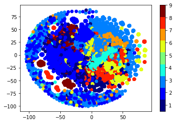

```python
# check out the course content for more explantion on tsne algorithm
# https://www.appliedaicourse.com/course/applied-ai-course-online/lessons/t-distributed-stochastic-neighbourhood-embeddingt-sne-part-1/

#multivariate analysis on byte files
#this is with perplexity 50
xtsne=TSNE(perplexity=50)
results=xtsne.fit_transform(result.drop(['ID','Class'], axis=1).fillna(0))
vis_x = results[:, 0]
vis_y = results[:, 1   ]
plt.scatter(vis_x, vis_y, c=data_y, cmap=plt.cm.get_cmap("jet", 9))
plt.colorbar(ticks=range(10))
plt.clim(0.5, 9)
plt.show()
```

### 4.2.3 Conclusion on EDA

We have taken only 52 features from asm files (after reading through many blogs and research papers)

The univariate analysis was done only on few important features.

Take-aways

- 1. Class 3 can be easily separated because of the frequency of segments,opcodes and keywords being less
- 2. Each feature has its unique importance in separating the Class labels.

## 4.3 Train and test split

```python
asm_x = result.drop(['ID','Class','.BSS:','.CODE'], axis=1)
asm_y = result['Class']
# split the data into test and train by maintaining same distribution of output varaible 'y_true' [stratify=y_true]
X_train_asm, X_test_asm, y_train_asm, y_test_asm = train_test_split(asm_x,asm_y ,stratify=asm_y,test_size=0.20)
X_train_asm, X_cv_asm, y_train_asm, y_cv_asm = train_test_split(X_train_asm, y_train_asm,stratify=y_train_asm,test_size=0.20)
```

## 4.4. Machine Learning models on features of .asm files

### 4.4.1 K-Nearest Neigbors

```
log_loss for k =  1 is 1.1128050516867647
log_loss for k =  3 is 1.1232378584493727
log_loss for k =  5 is 1.1336249187601248
log_loss for k =  7 is 1.1435836592725297
log_loss for k =  9 is 1.155274917468895
log_loss for k =  11 is 1.1658704657096088
log_loss for k =  13 is 1.1740674465229672
log_loss for k =  15 is 1.1823571369783807
log_loss for k =  17 is 1.1894153441882414
log_loss for k =  19 is 1.1968287262284452
```

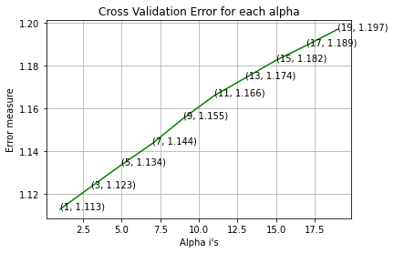

```
log loss for train data 0.44461102614404535
log loss for cv data 1.1128050516867647
log loss for test data 1.1129272182257988
Number of misclassified points  33.13391624482283
-------------------------------------------------- Confusion matrix --------------------------------------------------
```

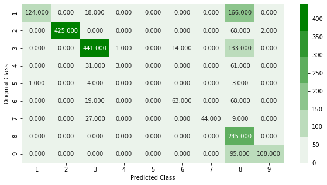

```
-------------------------------------------------- Precision matrix --------------------------------------------------
```

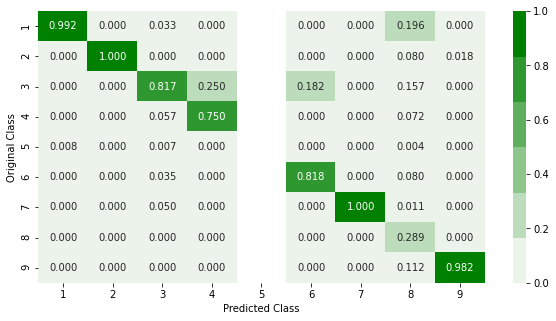

```
Sum of columns in precision matrix [ 1.  1.  1.  1. nan  1.  1.  1.  1.]
-------------------------------------------------- Recall matrix --------------------------------------------------
```

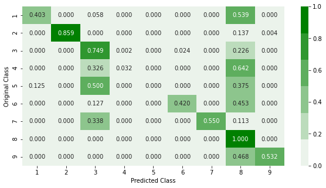

```
Sum of rows in precision matrix [1. 1. 1. 1. 1. 1. 1. 1. 1.]
```

```python
# find more about KNeighborsClassifier() here http://scikit-learn.org/stable/modules/generated/sklearn.neighbors.KNeighborsClassifier.html
# -------------------------
# default parameter
# KNeighborsClassifier(n_neighbors=5, weights=’uniform’, algorithm=’auto’, leaf_size=30, p=2,
# metric=’minkowski’, metric_params=None, n_jobs=1, **kwargs)

# methods of
# fit(X, y) : Fit the model using X as training data and y as target values
# predict(X):Predict the class labels for the provided data
# predict_proba(X):Return probability estimates for the test data X.
#-------------------------------------
# video link: https://www.appliedaicourse.com/course/applied-ai-course-online/lessons/k-nearest-neighbors-geometric-intuition-with-a-toy-example-1/
#-------------------------------------


# find more about CalibratedClassifierCV here at http://scikit-learn.org/stable/modules/generated/sklearn.calibration.CalibratedClassifierCV.html
# ----------------------------
# default paramters
# sklearn.calibration.CalibratedClassifierCV(base_estimator=None, method=’sigmoid’, cv=3)
#
# some of the methods of CalibratedClassifierCV()
# fit(X, y[, sample_weight])	Fit the calibrated model
# get_params([deep])	Get parameters for this estimator.
# predict(X)	Predict the target of new samples.
# predict_proba(X)	Posterior probabilities of classification
#-------------------------------------
# video link:
#-------------------------------------

alpha = [x for x in range(1, 21,2)]
cv_log_error_array=[]
for i in alpha:
    k_cfl=KNeighborsClassifier(n_neighbors=i)
    k_cfl.fit(X_train_asm,y_train_asm)
    sig_clf = CalibratedClassifierCV(k_cfl, method="sigmoid")
    sig_clf.fit(X_train_asm, y_train_asm)
    predict_y = sig_clf.predict_proba(X_cv_asm)
    cv_log_error_array.append(log_loss(y_cv_asm, predict_y, labels=k_cfl.classes_, eps=1e-15))

for i in range(len(cv_log_error_array)):
    print ('log_loss for k = ',alpha[i],'is',cv_log_error_array[i])

best_alpha = np.argmin(cv_log_error_array)
%matplotlib inline
fig, ax = plt.subplots()
ax.plot(alpha, cv_log_error_array,c='g')
for i, txt in enumerate(np.round(cv_log_error_array,3)):
    ax.annotate((alpha[i],np.round(txt,3)), (alpha[i],cv_log_error_array[i]))
plt.grid()
plt.title("Cross Validation Error for each alpha")
plt.xlabel("Alpha i's")
plt.ylabel("Error measure")
plt.show()

k_cfl=KNeighborsClassifier(n_neighbors=alpha[best_alpha])
k_cfl.fit(X_train_asm,y_train_asm)
sig_clf = CalibratedClassifierCV(k_cfl, method="sigmoid")
sig_clf.fit(X_train_asm, y_train_asm)
pred_y=sig_clf.predict(X_test_asm)


predict_y = sig_clf.predict_proba(X_train_asm)
print ('log loss for train data',log_loss(y_train_asm, predict_y))
predict_y = sig_clf.predict_proba(X_cv_asm)
print ('log loss for cv data',log_loss(y_cv_asm, predict_y))
predict_y = sig_clf.predict_proba(X_test_asm)
print ('log loss for test data',log_loss(y_test_asm, predict_y))
plot_confusion_matrix(y_test_asm,sig_clf.predict(X_test_asm))
```

### 4.4.2 Logistic Regression

```
log_loss for c =  1e-05 is 0.4853680393101723
log_loss for c =  0.0001 is 0.48344049804905337
log_loss for c =  0.001 is 0.4651545258753147
log_loss for c =  0.01 is 0.34222683358826195
log_loss for c =  0.1 is 0.20818604916128208
log_loss for c =  1 is 0.17162789410407123
log_loss for c =  10 is 0.17950977632732232
log_loss for c =  100 is 0.20912620537955076
log_loss for c =  1000 is 0.25349538717486286
```

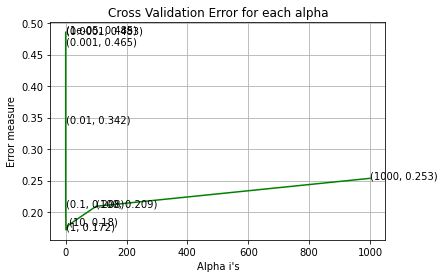

```
log loss for train data 0.04906307619690729
log loss for cv data 0.17162789410407123
log loss for test data 0.15652387661296083
Number of misclassified points  3.4974689369535206
-------------------------------------------------- Confusion matrix --------------------------------------------------
```

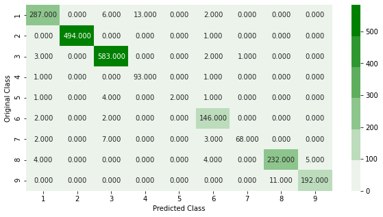

```
-------------------------------------------------- Precision matrix --------------------------------------------------
```

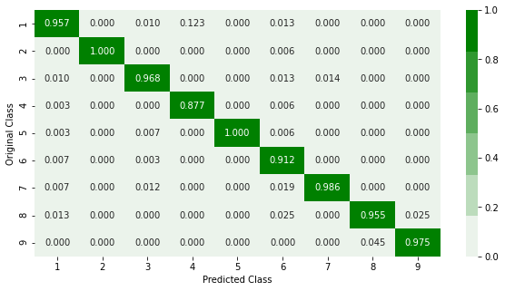

```
Sum of columns in precision matrix [1. 1. 1. 1. 1. 1. 1. 1. 1.]
-------------------------------------------------- Recall matrix --------------------------------------------------
```

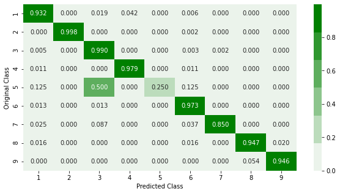

```
Sum of rows in precision matrix [1. 1. 1. 1. 1. 1. 1. 1. 1.]
```

```python
# read more about SGDClassifier() at http://scikit-learn.org/stable/modules/generated/sklearn.linear_model.SGDClassifier.html
# ------------------------------
# default parameters
# SGDClassifier(loss=’hinge’, penalty=’l2’, alpha=0.0001, l1_ratio=0.15, fit_intercept=True, max_iter=None, tol=None,
# shuffle=True, verbose=0, epsilon=0.1, n_jobs=1, random_state=None, learning_rate=’optimal’, eta0=0.0, power_t=0.5,
# class_weight=None, warm_start=False, average=False, n_iter=None)

# some of methods
# fit(X, y[, coef_init, intercept_init, …])	Fit linear model with Stochastic Gradient Descent.
# predict(X)	Predict class labels for samples in X.

#-------------------------------
# video link: https://www.appliedaicourse.com/course/applied-ai-course-online/lessons/geometric-intuition-1/
#------------------------------


alpha = [10 ** x for x in range(-5, 4)]
cv_log_error_array=[]
for i in alpha:
    logisticR=LogisticRegression(penalty='l2',C=i,class_weight='balanced')
    logisticR.fit(X_train_asm,y_train_asm)
    sig_clf = CalibratedClassifierCV(logisticR, method="sigmoid")
    sig_clf.fit(X_train_asm, y_train_asm)
    predict_y = sig_clf.predict_proba(X_cv_asm)
    cv_log_error_array.append(log_loss(y_cv_asm, predict_y, labels=logisticR.classes_, eps=1e-15))

for i in range(len(cv_log_error_array)):
    print ('log_loss for c = ',alpha[i],'is',cv_log_error_array[i])

best_alpha = np.argmin(cv_log_error_array)

%matplotlib inline
fig, ax = plt.subplots()
ax.plot(alpha, cv_log_error_array,c='g')
for i, txt in enumerate(np.round(cv_log_error_array,3)):
    ax.annotate((alpha[i],np.round(txt,3)), (alpha[i],cv_log_error_array[i]))
plt.grid()
plt.title("Cross Validation Error for each alpha")
plt.xlabel("Alpha i's")
plt.ylabel("Error measure")
plt.show()

logisticR=LogisticRegression(penalty='l2',C=alpha[best_alpha],class_weight='balanced')
logisticR.fit(X_train_asm,y_train_asm)
sig_clf = CalibratedClassifierCV(logisticR, method="sigmoid")
sig_clf.fit(X_train_asm, y_train_asm)

predict_y = sig_clf.predict_proba(X_train_asm)
print ('log loss for train data',(log_loss(y_train_asm, predict_y, labels=logisticR.classes_, eps=1e-15)))
predict_y = sig_clf.predict_proba(X_cv_asm)
print ('log loss for cv data',(log_loss(y_cv_asm, predict_y, labels=logisticR.classes_, eps=1e-15)))
predict_y = sig_clf.predict_proba(X_test_asm)
print ('log loss for test data',(log_loss(y_test_asm, predict_y, labels=logisticR.classes_, eps=1e-15)))
plot_confusion_matrix(y_test_asm,sig_clf.predict(X_test_asm))
```

### 4.4.3 Random Forest Classifier

```
log_loss for c =  10 is 0.2072670657560012
log_loss for c =  50 is 0.11630862401435027
log_loss for c =  100 is 0.10480428610204123
log_loss for c =  500 is 0.09583768172782696
log_loss for c =  1000 is 0.09494190235279833
log_loss for c =  2000 is 0.09339530054969708
log_loss for c =  3000 is 0.092680566294761
```

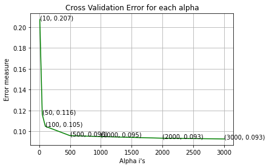

```
log loss for train data 0.01817532012902186
log loss for cv data 0.092680566294761
log loss for test data 0.08206900335960962
Number of misclassified points  1.4726184997699034
-------------------------------------------------- Confusion matrix --------------------------------------------------
```

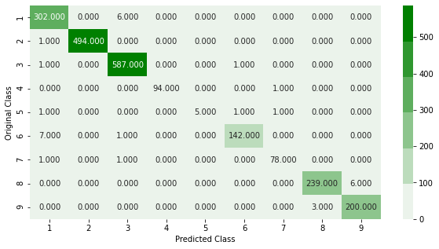

```
-------------------------------------------------- Precision matrix --------------------------------------------------
```

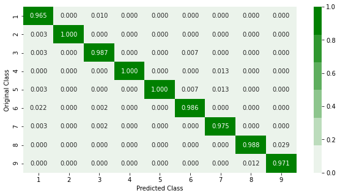

```
Sum of columns in precision matrix [1. 1. 1. 1. 1. 1. 1. 1. 1.]
-------------------------------------------------- Recall matrix --------------------------------------------------
```

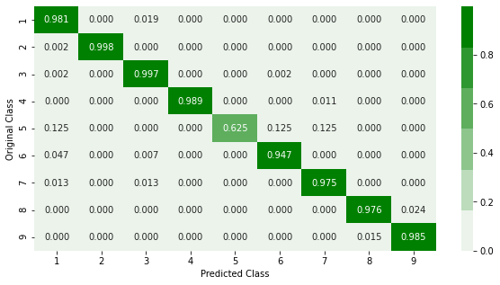

```
Sum of rows in precision matrix [1. 1. 1. 1. 1. 1. 1. 1. 1.]
```

```python
# --------------------------------
# default parameters
# sklearn.ensemble.RandomForestClassifier(n_estimators=10, criterion=’gini’, max_depth=None, min_samples_split=2,
# min_samples_leaf=1, min_weight_fraction_leaf=0.0, max_features=’auto’, max_leaf_nodes=None, min_impurity_decrease=0.0,
# min_impurity_split=None, bootstrap=True, oob_score=False, n_jobs=1, random_state=None, verbose=0, warm_start=False,
# class_weight=None)

# Some of methods of RandomForestClassifier()
# fit(X, y, [sample_weight])	Fit the SVM model according to the given training data.
# predict(X)	Perform classification on samples in X.
# predict_proba (X)	Perform classification on samples in X.

# some of attributes of  RandomForestClassifier()
# feature_importances_ : array of shape = [n_features]
# The feature importances (the higher, the more important the feature).

# --------------------------------
# video link: https://www.appliedaicourse.com/course/applied-ai-course-online/lessons/random-forest-and-their-construction-2/
# --------------------------------

alpha=[10,50,100,500,1000,2000,3000]
cv_log_error_array=[]
for i in alpha:
    r_cfl=RandomForestClassifier(n_estimators=i,random_state=42,n_jobs=-1)
    r_cfl.fit(X_train_asm,y_train_asm)
    sig_clf = CalibratedClassifierCV(r_cfl, method="sigmoid")
    sig_clf.fit(X_train_asm, y_train_asm)
    predict_y = sig_clf.predict_proba(X_cv_asm)
    cv_log_error_array.append(log_loss(y_cv_asm, predict_y, labels=r_cfl.classes_, eps=1e-15))

for i in range(len(cv_log_error_array)):
    print ('log_loss for c = ',alpha[i],'is',cv_log_error_array[i])


best_alpha = np.argmin(cv_log_error_array)

%matplotlib inline

fig, ax = plt.subplots()
ax.plot(alpha, cv_log_error_array,c='g')
for i, txt in enumerate(np.round(cv_log_error_array,3)):
    ax.annotate((alpha[i],np.round(txt,3)), (alpha[i],cv_log_error_array[i]))
plt.grid()
plt.title("Cross Validation Error for each alpha")
plt.xlabel("Alpha i's")
plt.ylabel("Error measure")
plt.show()

r_cfl=RandomForestClassifier(n_estimators=alpha[best_alpha],random_state=42,n_jobs=-1)
r_cfl.fit(X_train_asm,y_train_asm)
sig_clf = CalibratedClassifierCV(r_cfl, method="sigmoid")
sig_clf.fit(X_train_asm, y_train_asm)
predict_y = sig_clf.predict_proba(X_train_asm)
print ('log loss for train data',(log_loss(y_train_asm, predict_y, labels=sig_clf.classes_, eps=1e-15)))
predict_y = sig_clf.predict_proba(X_cv_asm)
print ('log loss for cv data',(log_loss(y_cv_asm, predict_y, labels=sig_clf.classes_, eps=1e-15)))
predict_y = sig_clf.predict_proba(X_test_asm)
print ('log loss for test data',(log_loss(y_test_asm, predict_y, labels=sig_clf.classes_, eps=1e-15)))
plot_confusion_matrix(y_test_asm,sig_clf.predict(X_test_asm))
```

### 4.4.4 XgBoost Classifier

```
log_loss for c =  5 is 0.1549142982666909
log_loss for c =  10 is 0.11021986195076798
log_loss for c =  50 is 0.06275195691776098
log_loss for c =  75 is 0.058473674968804526
log_loss for c =  100 is 0.056817066861299954
log_loss for c =  200 is 0.05351652976313305
```

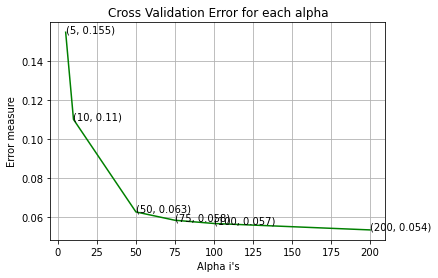

```
For values of best alpha =  200 The train log loss is: 0.0168573742206137
For values of best alpha =  200 The cross validation log loss is: 0.05351652976313305
For values of best alpha =  200 The test log loss is: 0.045533178785614095
Number of misclassified points  0.8283479061205707
-------------------------------------------------- Confusion matrix --------------------------------------------------
```

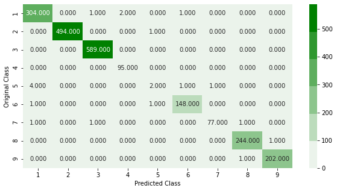

```
-------------------------------------------------- Precision matrix --------------------------------------------------
```

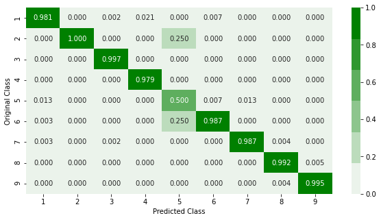

```
Sum of columns in precision matrix [1. 1. 1. 1. 1. 1. 1. 1. 1.]
-------------------------------------------------- Recall matrix --------------------------------------------------
```

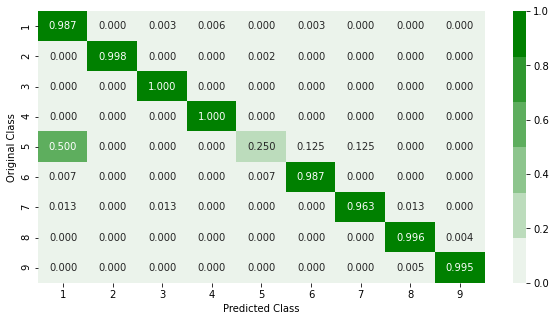

```
Sum of rows in precision matrix [1. 1. 1. 1. 1. 1. 1. 1. 1.]
```

```python
# Training a hyper-parameter tuned Xg-Boost regressor on our train data

# find more about XGBClassifier function here http://xgboost.readthedocs.io/en/latest/python/python_api.html?#xgboost.XGBClassifier
# -------------------------
# default paramters
# class xgboost.XGBClassifier(max_depth=3, learning_rate=0.1, n_estimators=100, silent=True,
# objective='binary:logistic', booster='gbtree', n_jobs=1, nthread=None, gamma=0, min_child_weight=1,
# max_delta_step=0, subsample=1, colsample_bytree=1, colsample_bylevel=1, reg_alpha=0, reg_lambda=1,
# scale_pos_weight=1, base_score=0.5, random_state=0, seed=None, missing=None, **kwargs)

# some of methods of RandomForestRegressor()
# fit(X, y, sample_weight=None, eval_set=None, eval_metric=None, early_stopping_rounds=None, verbose=True, xgb_model=None)
# get_params([deep])	Get parameters for this estimator.
# predict(data, output_margin=False, ntree_limit=0) : Predict with data. NOTE: This function is not thread safe.
# get_score(importance_type='weight') -> get the feature importance
# -----------------------
# video link2: https://www.appliedaicourse.com/course/applied-ai-course-online/lessons/what-are-ensembles/
# -----------------------

alpha=[5,10,50, 75, 100, 200]
cv_log_error_array=[]
for i in alpha:
    x_cfl=XGBClassifier(n_estimators=i)
    x_cfl.fit(X_train_asm,y_train_asm)
    sig_clf = CalibratedClassifierCV(x_cfl, method="sigmoid")
    sig_clf.fit(X_train_asm, y_train_asm)
    predict_y = sig_clf.predict_proba(X_cv_asm)
    cv_log_error_array.append(log_loss(y_cv_asm, predict_y, labels=x_cfl.classes_, eps=1e-15))

for i in range(len(cv_log_error_array)):
    print ('log_loss for c = ',alpha[i],'is',cv_log_error_array[i])


best_alpha = np.argmin(cv_log_error_array)

%matplotlib inline
fig, ax = plt.subplots()
ax.plot(alpha, cv_log_error_array,c='g')
for i, txt in enumerate(np.round(cv_log_error_array,3)):
    ax.annotate((alpha[i],np.round(txt,3)), (alpha[i],cv_log_error_array[i]))
plt.grid()
plt.title("Cross Validation Error for each alpha")
plt.xlabel("Alpha i's")
plt.ylabel("Error measure")
plt.show()

x_cfl=XGBClassifier(n_estimators=alpha[best_alpha])
x_cfl.fit(X_train_asm,y_train_asm)
sig_clf = CalibratedClassifierCV(x_cfl, method="sigmoid")
sig_clf.fit(X_train_asm, y_train_asm)

predict_y = sig_clf.predict_proba(X_train_asm)

print ('For values of best alpha = ', alpha[best_alpha], "The train log loss is:",log_loss(y_train_asm, predict_y))
predict_y = sig_clf.predict_proba(X_cv_asm)
print('For values of best alpha = ', alpha[best_alpha], "The cross validation log loss is:",log_loss(y_cv_asm, predict_y))
predict_y = sig_clf.predict_proba(X_test_asm)
print('For values of best alpha = ', alpha[best_alpha], "The test log loss is:",log_loss(y_test_asm, predict_y))
plot_confusion_matrix(y_test_asm,sig_clf.predict(X_test_asm))
```

### 4.4.5 Xgboost Classifier with best hyperparameters

```python
x_cfl=XGBClassifier()

prams={
    'learning_rate':[0.01,0.03,0.05,0.1,0.15,0.2],
     'n_estimators':[5,10,50, 75, 100, 200],
     'max_depth':[3,5,10],
    'colsample_bytree':[0.1,0.3,0.5,1],
    'subsample':[0.1,0.3,0.5,1]
}
random_cfl=RandomizedSearchCV(x_cfl,param_distributions=prams,verbose=10,n_jobs=-1,)
random_cfl.fit(X_train_asm,y_train_asm)
```

```
Fitting 5 folds for each of 10 candidates, totalling 50 fits
```

```
[Parallel(n_jobs=-1)]: Using backend LokyBackend with 2 concurrent workers.
[Parallel(n_jobs=-1)]: Done   1 tasks      | elapsed:  9.5min
[Parallel(n_jobs=-1)]: Done   4 tasks      | elapsed: 19.1min
[Parallel(n_jobs=-1)]: Done   9 tasks      | elapsed: 32.4min
[Parallel(n_jobs=-1)]: Done  14 tasks      | elapsed: 37.4min
[Parallel(n_jobs=-1)]: Done  21 tasks      | elapsed: 58.4min
[Parallel(n_jobs=-1)]: Done  28 tasks      | elapsed: 63.9min
[Parallel(n_jobs=-1)]: Done  37 tasks      | elapsed: 75.9min
[Parallel(n_jobs=-1)]: Done  46 tasks      | elapsed: 100.8min
[Parallel(n_jobs=-1)]: Done  50 out of  50 | elapsed: 105.2min finished
```

```
RandomizedSearchCV(cv=None, error_score=nan,
                   estimator=XGBClassifier(base_score=0.5, booster='gbtree',
                                           colsample_bylevel=1,
                                           colsample_bynode=1,
                                           colsample_bytree=1, gamma=0,
                                           learning_rate=0.1, max_delta_step=0,
                                           max_depth=3, min_child_weight=1,
                                           missing=None, n_estimators=100,
                                           n_jobs=1, nthread=None,
                                           objective='binary:logistic',
                                           random_state=0, reg_alpha=0,
                                           reg_lambda=1...
                                           seed=None, silent=None, subsample=1,
                                           verbosity=1),
                   iid='deprecated', n_iter=10, n_jobs=-1,
                   param_distributions={'colsample_bytree': [0.1, 0.3, 0.5, 1],
                                        'learning_rate': [0.01, 0.03, 0.05, 0.1,
                                                          0.15, 0.2],
                                        'max_depth': [3, 5, 10],
                                        'n_estimators': [5, 10, 50, 75, 100,
                                                         200],
                                        'subsample': [0.1, 0.3, 0.5, 1]},
                   pre_dispatch='2*n_jobs', random_state=None, refit=True,
                   return_train_score=False, scoring=None, verbose=10)
```

```python
print (random_cfl.best_params_)
```

```
{'subsample': 0.3, 'n_estimators': 200, 'max_depth': 10, 'learning_rate': 0.2, 'colsample_bytree': 0.3}
```

```python
# Training a hyper-parameter tuned Xg-Boost regressor on our train data

# find more about XGBClassifier function here http://xgboost.readthedocs.io/en/latest/python/python_api.html?#xgboost.XGBClassifier
# -------------------------
# default paramters
# class xgboost.XGBClassifier(max_depth=3, learning_rate=0.1, n_estimators=100, silent=True,
# objective='binary:logistic', booster='gbtree', n_jobs=1, nthread=None, gamma=0, min_child_weight=1,
# max_delta_step=0, subsample=1, colsample_bytree=1, colsample_bylevel=1, reg_alpha=0, reg_lambda=1,
# scale_pos_weight=1, base_score=0.5, random_state=0, seed=None, missing=None, **kwargs)

# some of methods of RandomForestRegressor()
# fit(X, y, sample_weight=None, eval_set=None, eval_metric=None, early_stopping_rounds=None, verbose=True, xgb_model=None)
# get_params([deep])	Get parameters for this estimator.
# predict(data, output_margin=False, ntree_limit=0) : Predict with data. NOTE: This function is not thread safe.
# get_score(importance_type='weight') -> get the feature importance
# -----------------------
# video link2: https://www.appliedaicourse.com/course/applied-ai-course-online/lessons/what-are-ensembles/
# -----------------------

x_cfl=XGBClassifier(n_estimators=200,subsample=0.3,learning_rate=0.2,colsample_bytree=0.3,max_depth=10)
x_cfl.fit(X_train_asm,y_train_asm)
c_cfl=CalibratedClassifierCV(x_cfl,method='sigmoid')
c_cfl.fit(X_train_asm,y_train_asm)

predict_y = c_cfl.predict_proba(X_train_asm)
print ('train loss',log_loss(y_train_asm, predict_y))
predict_y = c_cfl.predict_proba(X_cv_asm)
print ('cv loss',log_loss(y_cv_asm, predict_y))
predict_y = c_cfl.predict_proba(X_test_asm)
print ('test loss',log_loss(y_test_asm, predict_y))
```

```
train loss 0.01767014929396549
cv loss 0.035097405720627785
test loss 0.04937553694684861
```

## 4.5. Machine Learning models on features of both .asm and .bytes files

### 4.5.1. Merging both asm and byte file features

```python
byte_features_with_size_asm_pixel = pd.read_csv('result_with_size_asm_pixel.csv')

byte_features_with_size_asm_pixel = byte_features_with_size_asm_pixel.drop(columns = ['Unnamed: 0'])

# https://stackoverflow.com/a/29651514
def normalize(df):
    result1 = df.copy()
    for feature_name in df.columns:
        if (str(feature_name) != str('ID') and str(feature_name)!=str('Class')):
            max_value = df[feature_name].max()
            min_value = df[feature_name].min()
            result1[feature_name] = (df[feature_name] - min_value) / (max_value - min_value)
    return result1
result = normalize(byte_features_with_size_asm_pixel)
```

```python
byte_features_with_size_binary_pixel = pd.read_csv('result_with_size_binary_pixel.csv')

byte_features_with_size_binary_pixel = byte_features_with_size_binary_pixel.drop(columns = ['Unnamed: 0'])

# https://stackoverflow.com/a/29651514
def normalize(df):
    result1 = df.copy()
    for feature_name in df.columns:
        if (str(feature_name) != str('ID') and str(feature_name)!=str('Class')):
            max_value = df[feature_name].max()
            min_value = df[feature_name].min()
            result1[feature_name] = (df[feature_name] - min_value) / (max_value - min_value)
    return result1
result_binary = normalize(byte_features_with_size_binary_pixel)
```

```python
print(result.shape)
print(result_binary.shape)
```

```
(10861, 3022)
(10000, 3802)
```

```python
result_x = pd.merge(result_binary,result.drop(['Class'], axis=1),on='ID')
result_y = result_x['Class']
result_x = result_x.drop(['ID','.BSS:','.CODE','Class'], axis=1)
result_x.head()
```

|  | fd | b4 | 6e | 78 | de | 1a | 79 | 0d | 72 | a1 | bd | cf | 95 | b1 | 2e | f5 | f6 | e7 | 44 | 7b | 55 | e9 | 9a | 91 | e2 | 89 | 5b | 49 | 7f | … |
| --- | --- | --- | --- | --- | --- | --- | --- | --- | --- | --- | --- | --- | --- | --- | --- | --- | --- | --- | --- | --- | --- | --- | --- | --- | --- | --- | --- | --- | --- | --- |
| 0 | 0.020686 | 0.241691 | 0.245214 | 0.074610 | 0.193234 | 0.401354 | 0.258731 | 0.246999 | 0.213273 | 0.437874 | 0.238340 | 0.216853 | 0.286667 | 0.328151 | 0.467180 | 0.335873 | 0.490879 | 0.461716 | 0.398272 | 0.378394 | 0.493580 | 0.422644 | 0.418587 | 0.433838 | 0.352994 | 0.384688 | 0.446955 | 0.472160 | 0.359241 | … |
| 1 | 0.026070 | 0.240115 | 0.244722 | 0.074600 | 0.193291 | 0.401774 | 0.258677 | 0.246983 | 0.212736 | 0.436829 | 0.238462 | 0.216140 | 0.285696 | 0.328129 | 0.467268 | 0.336115 | 0.490547 | 0.461300 | 0.398226 | 0.377722 | 0.493864 | 0.422887 | 0.418750 | 0.432646 | 0.352344 | 0.387095 | 0.449398 | 0.474864 | 0.359372 | … |
| 2 | 0.011070 | 0.243824 | 0.248488 | 0.075041 | 0.193600 | 0.401087 | 0.258808 | 0.247447 | 0.213158 | 0.437002 | 0.238877 | 0.216545 | 0.286434 | 0.327896 | 0.467292 | 0.336178 | 0.490810 | 0.461701 | 0.398269 | 0.378627 | 0.493253 | 0.422449 | 0.418851 | 0.433947 | 0.352892 | 0.385367 | 0.447833 | 0.473007 | 0.359159 | … |
| 3 | 0.122864 | 0.215803 | 0.212897 | 0.070061 | 0.194897 | 0.403846 | 0.258361 | 0.241398 | 0.213872 | 0.438413 | 0.233919 | 0.214436 | 0.285582 | 0.331177 | 0.468386 | 0.339904 | 0.491401 | 0.464936 | 0.396859 | 0.373358 | 0.502514 | 0.413450 | 0.412462 | 0.444996 | 0.343904 | 0.380996 | 0.447148 | 0.449477 | 0.347965 | … |
| 4 | 0.076206 | 0.228028 | 0.230242 | 0.073189 | 0.192625 | 0.403211 | 0.258394 | 0.245530 | 0.211028 | 0.436740 | 0.237324 | 0.215298 | 0.284060 | 0.328597 | 0.466846 | 0.336267 | 0.489472 | 0.461791 | 0.398577 | 0.373307 | 0.495240 | 0.424410 | 0.418833 | 0.428943 | 0.351054 | 0.390317 | 0.452094 | 0.477033 | 0.360055 | … |

5 rows × 6818 columns

### 4.5.2. Multivariate Analysis on final fearures

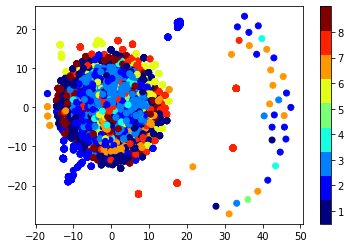

```python
xtsne=TSNE(perplexity=50)
results=xtsne.fit_transform(result_x)
vis_x = results[:, 0]
vis_y = results[:, 1]
%matplotlib inline
plt.scatter(vis_x, vis_y, c=result_y, cmap=plt.cm.get_cmap("jet", 9))
plt.colorbar(ticks=range(9))
plt.clim(0.5, 9)
plt.show()
```

### 4.5.3. Train and Test split

```python
X_train, X_test_merge, y_train, y_test_merge = train_test_split(result_x, result_y,stratify=result_y,test_size=0.20)
X_train_merge, X_cv_merge, y_train_merge, y_cv_merge = train_test_split(X_train, y_train,stratify=y_train,test_size=0.20)
```

### 4.5.4. Random Forest Classifier on final features

```
log_loss for c =  10 is 0.1648228157139891
log_loss for c =  50 is 0.11264535062238791
log_loss for c =  100 is 0.10296612343298973
log_loss for c =  500 is 0.09356457153200276
log_loss for c =  1000 is 0.09288354041113073
log_loss for c =  2000 is 0.0928126102300245
log_loss for c =  3000 is 0.09224195781784245
```

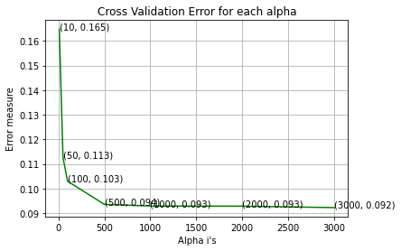

```
For values of best alpha =  3000 The train log loss is: 0.02407627367677853
For values of best alpha =  3000 The cross validation log loss is: 0.09224195781784245
For values of best alpha =  3000 The test log loss is: 0.08953597147086867
```

```python
# --------------------------------
# default parameters
# sklearn.ensemble.RandomForestClassifier(n_estimators=10, criterion=’gini’, max_depth=None, min_samples_split=2,
# min_samples_leaf=1, min_weight_fraction_leaf=0.0, max_features=’auto’, max_leaf_nodes=None, min_impurity_decrease=0.0,
# min_impurity_split=None, bootstrap=True, oob_score=False, n_jobs=1, random_state=None, verbose=0, warm_start=False,
# class_weight=None)

# Some of methods of RandomForestClassifier()
# fit(X, y, [sample_weight])	Fit the SVM model according to the given training data.
# predict(X)	Perform classification on samples in X.
# predict_proba (X)	Perform classification on samples in X.

# some of attributes of  RandomForestClassifier()
# feature_importances_ : array of shape = [n_features]
# The feature importances (the higher, the more important the feature).

# --------------------------------
# video link: https://www.appliedaicourse.com/course/applied-ai-course-online/lessons/random-forest-and-their-construction-2/
# --------------------------------
%matplotlib inline
alpha=[10,50,100,500,1000,2000,3000]
cv_log_error_array=[]
from sklearn.ensemble import RandomForestClassifier
for i in alpha:
    r_cfl=RandomForestClassifier(n_estimators=i,random_state=42,n_jobs=-1)
    r_cfl.fit(X_train_merge,y_train_merge)
    sig_clf = CalibratedClassifierCV(r_cfl, method="sigmoid")
    sig_clf.fit(X_train_merge, y_train_merge)
    predict_y = sig_clf.predict_proba(X_cv_merge)
    cv_log_error_array.append(log_loss(y_cv_merge, predict_y, labels=r_cfl.classes_, eps=1e-15))

for i in range(len(cv_log_error_array)):
    print ('log_loss for c = ',alpha[i],'is',cv_log_error_array[i])


best_alpha = np.argmin(cv_log_error_array)

fig, ax = plt.subplots()
ax.plot(alpha, cv_log_error_array,c='g')
for i, txt in enumerate(np.round(cv_log_error_array,3)):
    ax.annotate((alpha[i],np.round(txt,3)), (alpha[i],cv_log_error_array[i]))

plt.grid()
plt.title("Cross Validation Error for each alpha")
plt.xlabel("Alpha i's")
plt.ylabel("Error measure")
plt.show()


r_cfl=RandomForestClassifier(n_estimators=alpha[best_alpha],random_state=42,n_jobs=-1)
r_cfl.fit(X_train_merge,y_train_merge)
sig_clf = CalibratedClassifierCV(r_cfl, method="sigmoid")
sig_clf.fit(X_train_merge, y_train_merge)

predict_y = sig_clf.predict_proba(X_train_merge)
print ('For values of best alpha = ', alpha[best_alpha], "The train log loss is:",log_loss(y_train_merge, predict_y))
predict_y = sig_clf.predict_proba(X_cv_merge)
print('For values of best alpha = ', alpha[best_alpha], "The cross validation log loss is:",log_loss(y_cv_merge, predict_y))
predict_y = sig_clf.predict_proba(X_test_merge)
print('For values of best alpha = ', alpha[best_alpha], "The test log loss is:",log_loss(y_test_merge, predict_y))
```

### 4.5.5. XgBoost Classifier on final features

```
log_loss for c =  5 is 0.13956465761568346
log_loss for c =  10 is 0.12227040025832969
log_loss for c =  50 is 0.04955315218213867
log_loss for c =  75 is 0.040258576342046666
log_loss for c =  100 is 0.03690728920223634
log_loss for c =  200 is 0.03494765927579046
```

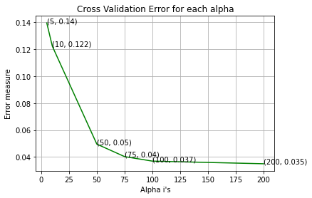

```python
# Training a hyper-parameter tuned Xg-Boost regressor on our train data

# find more about XGBClassifier function here http://xgboost.readthedocs.io/en/latest/python/python_api.html?#xgboost.XGBClassifier
# -------------------------
# default paramters
# class xgboost.XGBClassifier(max_depth=3, learning_rate=0.1, n_estimators=100, silent=True,
# objective='binary:logistic', booster='gbtree', n_jobs=1, nthread=None, gamma=0, min_child_weight=1,
# max_delta_step=0, subsample=1, colsample_bytree=1, colsample_bylevel=1, reg_alpha=0, reg_lambda=1,
# scale_pos_weight=1, base_score=0.5, random_state=0, seed=None, missing=None, **kwargs)

# some of methods of RandomForestRegressor()
# fit(X, y, sample_weight=None, eval_set=None, eval_metric=None, early_stopping_rounds=None, verbose=True, xgb_model=None)
# get_params([deep])	Get parameters for this estimator.
# predict(data, output_margin=False, ntree_limit=0) : Predict with data. NOTE: This function is not thread safe.
# get_score(importance_type='weight') -> get the feature importance
# -----------------------
# video link2: https://www.appliedaicourse.com/course/applied-ai-course-online/lessons/what-are-ensembles/
# -----------------------
%matplotlib inline
alpha=[5,10,50, 75, 100, 200]
cv_log_error_array=[]
for i in alpha:
    x_cfl=XGBClassifier(n_estimators=i)
    x_cfl.fit(X_train_merge,y_train_merge)
    sig_clf = CalibratedClassifierCV(x_cfl, method="sigmoid")
    sig_clf.fit(X_train_merge, y_train_merge)
    predict_y = sig_clf.predict_proba(X_cv_merge)
    cv_log_error_array.append(log_loss(y_cv_merge, predict_y, labels=x_cfl.classes_, eps=1e-15))

for i in range(len(cv_log_error_array)):
    print ('log_loss for c = ',alpha[i],'is',cv_log_error_array[i])


best_alpha = np.argmin(cv_log_error_array)

fig, ax = plt.subplots()
ax.plot(alpha, cv_log_error_array,c='g')
for i, txt in enumerate(np.round(cv_log_error_array,3)):
    ax.annotate((alpha[i],np.round(txt,3)), (alpha[i],cv_log_error_array[i]))
plt.grid()
plt.title("Cross Validation Error for each alpha")
plt.xlabel("Alpha i's")
plt.ylabel("Error measure")
plt.show()

x_cfl=XGBClassifier(n_estimators=alpha[best_alpha],random_state=42,n_jobs=-1)
x_cfl.fit(X_train_merge,y_train_merge,verbose=True)
sig_clf = CalibratedClassifierCV(x_cfl, method="sigmoid")
sig_clf.fit(X_train_merge, y_train_merge)
```

### 4.5.5. XgBoost Classifier on final features with best hyper parameters using Random search

```python
x_cfl=XGBClassifier()

prams={
    'learning_rate':[0.01,0.03,0.05,0.1,0.15,0.2],
     'n_estimators':[5,10,50, 75, 100, 200],
     'max_depth':[3,5,10],
    'colsample_bytree':[0.1,0.3,0.5,1],
    'subsample':[0.1,0.3,0.5,1]
}
random_cfl=RandomizedSearchCV(x_cfl,param_distributions=prams,verbose=10,n_jobs=-1,)
random_cfl.fit(X_train_merge, y_train_merge)
```

```
Fitting 5 folds for each of 10 candidates, totalling 50 fits
```

```
[Parallel(n_jobs=-1)]: Using backend LokyBackend with 2 concurrent workers.
[Parallel(n_jobs=-1)]: Done   1 tasks      | elapsed: 45.4min
[Parallel(n_jobs=-1)]: Done   4 tasks      | elapsed: 91.3min
[Parallel(n_jobs=-1)]: Done   9 tasks      | elapsed: 113.6min
[Parallel(n_jobs=-1)]: Done  14 tasks      | elapsed: 135.7min
[Parallel(n_jobs=-1)]: Done  21 tasks      | elapsed: 206.5min
[Parallel(n_jobs=-1)]: Done  28 tasks      | elapsed: 333.8min
[Parallel(n_jobs=-1)]: Done  37 tasks      | elapsed: 405.9min
[Parallel(n_jobs=-1)]: Done  46 tasks      | elapsed: 467.5min
[Parallel(n_jobs=-1)]: Done  50 out of  50 | elapsed: 469.6min finished
```

```
RandomizedSearchCV(cv=None, error_score=nan,
                   estimator=XGBClassifier(base_score=0.5, booster='gbtree',
                                           colsample_bylevel=1,
                                           colsample_bynode=1,
                                           colsample_bytree=1, gamma=0,
                                           learning_rate=0.1, max_delta_step=0,
                                           max_depth=3, min_child_weight=1,
                                           missing=None, n_estimators=100,
                                           n_jobs=1, nthread=None,
                                           objective='binary:logistic',
                                           random_state=0, reg_alpha=0,
                                           reg_lambda=1...
                                           seed=None, silent=None, subsample=1,
                                           verbosity=1),
                   iid='deprecated', n_iter=10, n_jobs=-1,
                   param_distributions={'colsample_bytree': [0.1, 0.3, 0.5, 1],
                                        'learning_rate': [0.01, 0.03, 0.05, 0.1,
                                                          0.15, 0.2],
                                        'max_depth': [3, 5, 10],
                                        'n_estimators': [5, 10, 50, 75, 100,
                                                         200],
                                        'subsample': [0.1, 0.3, 0.5, 1]},
                   pre_dispatch='2*n_jobs', random_state=None, refit=True,
                   return_train_score=False, scoring=None, verbose=10)
```

```python
print (random_cfl.best_params_)
```

```
{'subsample': 1, 'n_estimators': 50, 'max_depth': 3, 'learning_rate': 0.2, 'colsample_bytree': 0.3}
```

```python
# find more about XGBClassifier function here http://xgboost.readthedocs.io/en/latest/python/python_api.html?#xgboost.XGBClassifier
# -------------------------
# default paramters
# class xgboost.XGBClassifier(max_depth=3, learning_rate=0.1, n_estimators=100, silent=True,
# objective='binary:logistic', booster='gbtree', n_jobs=1, nthread=None, gamma=0, min_child_weight=1,
# max_delta_step=0, subsample=1, colsample_bytree=1, colsample_bylevel=1, reg_alpha=0, reg_lambda=1,
# scale_pos_weight=1, base_score=0.5, random_state=0, seed=None, missing=None, **kwargs)

# some of methods of RandomForestRegressor()
# fit(X, y, sample_weight=None, eval_set=None, eval_metric=None, early_stopping_rounds=None, verbose=True, xgb_model=None)
# get_params([deep])	Get parameters for this estimator.
# predict(data, output_margin=False, ntree_limit=0) : Predict with data. NOTE: This function is not thread safe.
# get_score(importance_type='weight') -> get the feature importance
# -----------------------
# video link2: https://www.appliedaicourse.com/course/applied-ai-course-online/lessons/what-are-ensembles/
# -----------------------
x_cfl=XGBClassifier(n_estimators=50,max_depth=3,learning_rate=0.2,colsample_bytree=0.3,subsample=1)
x_cfl.fit(X_train_merge,y_train_merge,verbose=True)
sig_clf = CalibratedClassifierCV(x_cfl, method="sigmoid")
sig_clf.fit(X_train_merge, y_train_merge)


predict_y = sig_clf.predict_proba(X_train_merge)
print("The train log loss is:",log_loss(y_train_merge, predict_y))
predict_y = sig_clf.predict_proba(X_cv_merge)
print("The cross validation log loss is:",log_loss(y_cv_merge, predict_y))
predict_y = sig_clf.predict_proba(X_test_merge)
print("The test log loss is:",log_loss(y_test_merge, predict_y))
```

```
The train log loss is: 0.013679148302896717
The cross validation log loss is: 0.036970956585008
The test log loss is: 0.027328810784065394
```